# Wish - Summer Clothing Sale Predictions

Background: Wish is an eCommerce website. The platform keeps track of ratings, merchant ratings, and other factors as they relate to product listings. It is important to determine what drives unit sales for products beyond factors such as ratings. The dataset involved in this project solely contained Summer Clothing. Thus, I set out to model unit sales as they related to variables associated with each product.

The dataset for this project can be found at:

https://www.kaggle.com/jmmvutu/summer-products-and-sales-in-ecommerce-wish

The purpose of this notebook is to analyze the driving factors behind Wish Summer Clothing Unit sales. I used Microsoft Azure SQL to organize the data prior to any analysis done here. I will include the SQL code in each section of the project to show how this organization was done.

There are 3 parts of this project.

1. Creating correlation table to understand which quantitative values had strongest correlations.
2. Doing a Multilinear Regression and a Polynomial Regression to see if I can create a model that will determine unit sales based on multiple variables.
3. Understanding how clothing color can affect sales.

# Step 1: Correlation Table

**Why:** I am creating a correlation table to see which factors are related to unit sales. This should offer an informative answer as to what future decisions should be made regarding sales strategy.

**How:** I will use Matplotlib, Scikit, and Pandas to clean the data and create a correlation table.

# Associated SQL

select title, units_sold, price, (retail_price - price) discount, uses_ad_boosts, rating, merchant_rating from summer-products

**A: Import Dataset and Libraries**

```python
import matplotlib.pyplot as plt
import pandas as pd
import numpy as np
import seaborn as sns
import statistics as stats
from sklearn.linear_model import LinearRegression
from sklearn.pipeline import Pipeline
from sklearn.preprocessing import StandardScaler
from sklearn.preprocessing import PolynomialFeatures
from sklearn.metrics import r2_score
from sklearn.linear_model import Ridge
import statsmodels.api as sm
```

```python
df = pd.read_csv('/Users/naasirhaleem/Desktop/Kaggle Projects/Wish/intermediate_csvs/Correlation/wishcorrelation.csv')
```

```python
df.head()
```

|  | title | units_sold | price | discount | uses_ad_boosts | rating | merchant_rating |
| --- | --- | --- | --- | --- | --- | --- | --- |
| 0 | 2020 Summer Vintage Flamingo Print Pajamas Se... | 100 | 16.00 | -2.00 | 0 | 3.76 | 4.128521 |
| 1 | SSHOUSE Summer Casual Sleeveless Soirée Party ... | 20000 | 8.00 | 14.00 | 1 | 3.45 | 3.899673 |
| 2 | 2020 Nouvelle Arrivée Femmes Printemps et Été ... | 100 | 8.00 | 35.00 | 0 | 3.57 | 3.989831 |
| 3 | Hot Summer Cool T-shirt pour les femmes Mode T... | 5000 | 8.00 | 0.00 | 1 | 4.03 | 4.020435 |
| 4 | Femmes Shorts d'été à lacets taille élastique ... | 100 | 2.72 | 0.28 | 1 | 3.10 | 4.001588 |

**B: Visualize Units solds as they relate to Price**

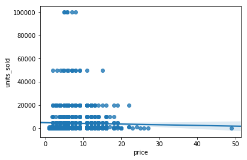

```python
sns.regplot(x = "price", y = "units_sold", data = df)
```

**Note: Seems like weak negative correlation which would make sense but need to actually visualize it**

```python
df.corr()
```

|  | units_sold | price | discount | uses_ad_boosts | rating | merchant_rating |
| --- | --- | --- | --- | --- | --- | --- |
| units_sold | 1.000000 | -0.024815 | 0.016369 | -0.016055 | 0.039478 | 0.122504 |
| price | -0.024815 | 1.000000 | 0.180939 | -0.073269 | 0.053469 | 0.047121 |
| discount | 0.016369 | 0.180939 | 1.000000 | -0.026678 | 0.017741 | 0.049871 |
| uses_ad_boosts | -0.016055 | -0.073269 | -0.026678 | 1.000000 | -0.049410 | -0.022564 |
| rating | 0.039478 | 0.053469 | 0.017741 | -0.049410 | 1.000000 | 0.237305 |
| merchant_rating | 0.122504 | 0.047121 | 0.049871 | -0.022564 | 0.237305 | 1.000000 |

**Note: It does not appear that any of these factors have a strong effect on units sold. Lets move on to the multilinear regression and polynomial regression.**

# Step 2: Create Multilinear Regression and Polynomial Regression

**Why:** I am performing multilinear regression and polynomial regression in order to create a model that will reliably predict units sold based on these factors.

**How:** Going to use sklearn module

# Associated SQL

**MLR and PR 1:** select title, units_sold, price, (retail_price - price) discount, uses_ad_boosts, rating_count, merchant_rating_count, rating, merchant_rating, rating_five_count,product_variation_inventory, shipping_option_price, countries_shipped_to, has_urgency_banner from summer-products

**MLR and PR 2:** select units_sold, (retail_price - price) discount, uses_ad_boosts, rating_count, merchant_rating_count, product_variation_inventory, has_urgency_banner from summer-products

**A: Initiate Linear Regression**

```python
lm = LinearRegression()
```

**A1: Want to test against merchant rating to see if that yields anything**

```python
lm.fit(df[['merchant_rating']],df['units_sold'])
```

```
LinearRegression(copy_X=True, fit_intercept=True, n_jobs=None,
         normalize=False)
```

```python
lm.score(df[['merchant_rating']],df['units_sold'])
```

```
0.015007179251857128
```

**Note: R^2 here is about 2% so not terribly interesting since only 2% of data is being explained by merchant rating**

**B: Group all of factors**

```python
Z = df[['price','discount','uses_ad_boosts','rating','merchant_rating']]
```

**C: Run Regression**

```python
lm.fit(Z, df['units_sold'])
```

```
LinearRegression(copy_X=True, fit_intercept=True, n_jobs=None,
         normalize=False)
```

```python
a = lm.intercept_
```

```python
b = lm.coef_
```

```python
lm.fit(Z, df['units_sold'])
```

```
LinearRegression(copy_X=True, fit_intercept=True, n_jobs=None,
         normalize=False)
```

```python
c = lm.score(Z, df['units_sold'])
```

```python
print('Model is:',a,'+',b[0],'*price +',b[1],'*discount +',b[2],'*uses_ad_boosts +',b[3],'*rating +',b[4],'*merchant_rating')
print('R^2 is',c )
```

```
Model is: -17889.293851496997 + -83.56971252285267 *price + 5.130881118955638 *discount + -281.3203873545076 *uses_ad_boosts + 214.32953216712423 *rating + 5493.114768167924 *merchant_rating
R^2 is 0.016567734865267303
```

The model is shown here but my R^2 is extremely low. We'll see if a polynomial regression will work better. If not, then there may be more data cutting required.

**A: Inititate Pipeline and Polynomial Regression**

```python
pr=PolynomialFeatures(degree=2)
pr
```

```
PolynomialFeatures(degree=2, include_bias=True, interaction_only=False)
```

```python
Z_pr=pr.fit_transform(Z)
```

```python
Input=[('scale',StandardScaler()), ('polynomial', PolynomialFeatures(include_bias=False)), ('model',LinearRegression())]
```

```python
pipe=Pipeline(Input)
pipe
```

```
Pipeline(memory=None,
     steps=[('scale', StandardScaler(copy=True, with_mean=True, with_std=True)), ('polynomial', PolynomialFeatures(degree=2, include_bias=False, interaction_only=False)), ('model', LinearRegression(copy_X=True, fit_intercept=True, n_jobs=None,
         normalize=False))])
```

```python
y = df['units_sold']
```

```python
pipe.fit(Z,y)
```

```
Pipeline(memory=None,
     steps=[('scale', StandardScaler(copy=True, with_mean=True, with_std=True)), ('polynomial', PolynomialFeatures(degree=2, include_bias=False, interaction_only=False)), ('model', LinearRegression(copy_X=True, fit_intercept=True, n_jobs=None,
         normalize=False))])
```

**B: Run Regression**

```python
ypipe=pipe.predict(Z)
ypipe
```

```
array([4000.1875, 4174.875 , 4932.75  , ..., 5465.    ,    7.9375,
       5389.1875])
```

**C: Check R^2**

```python
pipe.score(Z,y)
```

```
0.040095500693456354
```

**Note: This R^2 accounts for more of the data than before so a polynomial regression will help.**

**E: Read in another dataset with more factors passed in**

```python
dff = pd.read_csv('/Users/naasirhaleem/Desktop/Kaggle Projects/Wish/intermediate_csvs/Correlation/wishcorrelation2.csv')
```

**Note: Have to replace any NULLS so that they do not affect regressions**

```python
dff["has_urgency_banner"].replace(np.nan,0, inplace = True)
dff["rating_five_count"].replace(np.nan,0,inplace = True)
```

```python
dff.describe()
```

|  | units_sold | price | discount | uses_ad_boosts | rating_count | merchant_rating_count | rating | merchant_rating | rating_five_count | product_variation_inventory | shipping_option_price | countries_shipped_to | has_urgency_banner |
| --- | --- | --- | --- | --- | --- | --- | --- | --- | --- | --- | --- | --- | --- |
| count | 1573.000000 | 1573.000000 | 1573.000000 | 1573.000000 | 1573.000000 | 1.573000e+03 | 1573.000000 | 1573.000000 | 1573.000000 | 1573.000000 | 1573.000000 | 1573.000000 | 1573.000000 |
| mean | 4339.005086 | 8.325372 | 14.963249 | 0.432931 | 889.659250 | 2.649583e+04 | 3.820896 | 4.032345 | 429.611570 | 33.081373 | 2.345200 | 40.456453 | 0.300699 |
| std | 9356.539302 | 3.932030 | 29.399090 | 0.495639 | 1983.928834 | 7.847446e+04 | 0.515374 | 0.204768 | 968.882684 | 21.353137 | 1.024371 | 20.301203 | 0.458708 |
| min | 1.000000 | 1.000000 | -7.000000 | 0.000000 | 0.000000 | 0.000000e+00 | 1.000000 | 2.333333 | 0.000000 | 1.000000 | 1.000000 | 6.000000 | 0.000000 |
| 25% | 100.000000 | 5.810000 | -1.000000 | 0.000000 | 24.000000 | 1.987000e+03 | 3.550000 | 3.917353 | 10.000000 | 6.000000 | 2.000000 | 31.000000 | 0.000000 |
| 50% | 1000.000000 | 8.000000 | 0.200000 | 0.000000 | 150.000000 | 7.936000e+03 | 3.850000 | 4.040650 | 72.000000 | 50.000000 | 2.000000 | 40.000000 | 0.000000 |
| 75% | 5000.000000 | 11.000000 | 18.000000 | 1.000000 | 855.000000 | 2.456400e+04 | 4.110000 | 4.161797 | 394.000000 | 50.000000 | 3.000000 | 43.000000 | 1.000000 |
| max | 100000.000000 | 49.000000 | 244.000000 | 1.000000 | 20744.000000 | 2.174765e+06 | 5.000000 | 5.000000 | 11548.000000 | 50.000000 | 12.000000 | 140.000000 | 1.000000 |

**E: Correlation Table**

```python
dff.corr()
```

|  | units_sold | price | discount | uses_ad_boosts | rating_count | merchant_rating_count | rating | merchant_rating | rating_five_count | product_variation_inventory | shipping_option_price | countries_shipped_to | has_urgency_banner |
| --- | --- | --- | --- | --- | --- | --- | --- | --- | --- | --- | --- | --- | --- |
| units_sold | 1.000000 | -0.024815 | 0.016369 | -0.016055 | 0.899464 | 0.272897 | 0.039478 | 0.122504 | 0.876972 | 0.133846 | -0.030987 | -0.013553 | -0.023891 |
| price | -0.024815 | 1.000000 | 0.180939 | -0.073269 | -0.001911 | -0.023790 | 0.053469 | 0.047121 | -0.000660 | 0.274819 | 0.872580 | -0.033312 | -0.021222 |
| discount | 0.016369 | 0.180939 | 1.000000 | -0.026678 | 0.055884 | 0.033292 | 0.017741 | 0.049871 | 0.054170 | 0.085961 | 0.154373 | 0.041215 | -0.008460 |
| uses_ad_boosts | -0.016055 | -0.073269 | -0.026678 | 1.000000 | -0.043936 | 0.029735 | -0.049410 | -0.022564 | -0.043323 | -0.135384 | -0.061495 | -0.017439 | 0.017414 |
| rating_count | 0.899464 | -0.001911 | 0.055884 | -0.043936 | 1.000000 | 0.258168 | 0.054112 | 0.141255 | 0.983434 | 0.134246 | -0.005928 | -0.001843 | -0.004729 |
| merchant_rating_count | 0.272897 | -0.023790 | 0.033292 | 0.029735 | 0.258168 | 1.000000 | 0.033837 | 0.136401 | 0.247231 | 0.083577 | -0.033675 | 0.111769 | 0.002627 |
| rating | 0.039478 | 0.053469 | 0.017741 | -0.049410 | 0.054112 | 0.033837 | 1.000000 | 0.237305 | 0.097029 | 0.031954 | 0.067963 | 0.046423 | -0.037736 |
| merchant_rating | 0.122504 | 0.047121 | 0.049871 | -0.022564 | 0.141255 | 0.136401 | 0.237305 | 1.000000 | 0.162636 | 0.158771 | 0.054648 | 0.134551 | 0.001066 |
| rating_five_count | 0.876972 | -0.000660 | 0.054170 | -0.043323 | 0.983434 | 0.247231 | 0.097029 | 0.162636 | 1.000000 | 0.126979 | -0.000976 | -0.001279 | -0.009222 |
| product_variation_inventory | 0.133846 | 0.274819 | 0.085961 | -0.135384 | 0.134246 | 0.083577 | 0.031954 | 0.158771 | 0.126979 | 1.000000 | 0.265225 | 0.116129 | 0.004385 |
| shipping_option_price | -0.030987 | 0.872580 | 0.154373 | -0.061495 | -0.005928 | -0.033675 | 0.067963 | 0.054648 | -0.000976 | 0.265225 | 1.000000 | -0.051783 | -0.012563 |
| countries_shipped_to | -0.013553 | -0.033312 | 0.041215 | -0.017439 | -0.001843 | 0.111769 | 0.046423 | 0.134551 | -0.001279 | 0.116129 | -0.051783 | 1.000000 | -0.008259 |
| has_urgency_banner | -0.023891 | -0.021222 | -0.008460 | 0.017414 | -0.004729 | 0.002627 | -0.037736 | 0.001066 | -0.009222 | 0.004385 | -0.012563 | -0.008259 | 1.000000 |

**Note: Very strong correlation between rating count and units sold. This is obvious because intuitively the more units that are sold, the greater the number of reviews.**

```python
Z = dff[['price', 'discount', 'uses_ad_boosts', 'rating_count', 'merchant_rating_count','rating', 'merchant_rating', 'rating_five_count','product_variation_inventory', 'shipping_option_price', 'countries_shipped_to', 'has_urgency_banner']]
```

**F: Multilinear Regression II**

```python
lm.fit(Z,y)
```

```
LinearRegression(copy_X=True, fit_intercept=True, n_jobs=None,
         normalize=False)
```

```python
lm.score(Z,y)
```

```
0.815644718787133
```

**Note: Doing MLR significantly increased our R^2 with the added factors**

**G: OLS Table (Just wanted to see whether my p-values are out of whack)**

```python
X = Z
y = y
X2 = sm.add_constant(X)
est = sm.OLS(y, X2)
est2 = est.fit()
print(est2.summary())
```

```
                            OLS Regression Results
==============================================================================
Dep. Variable:             units_sold   R-squared:                       0.816
Model:                            OLS   Adj. R-squared:                  0.814
Method:                 Least Squares   F-statistic:                     575.2
Date:                Thu, 01 Oct 2020   Prob (F-statistic):               0.00
Time:                        16:57:04   Log-Likelihood:                -15285.
No. Observations:                1573   AIC:                         3.060e+04
Df Residuals:                    1560   BIC:                         3.067e+04
Df Model:                          12
Covariance Type:            nonrobust
===============================================================================================
                                  coef    std err          t      P>|t|      [0.025      0.975]
-----------------------------------------------------------------------------------------------
const                        1291.3240   2095.835      0.616      0.538   -2819.627    5402.275
price                          -7.3253     53.480     -0.137      0.891    -112.226      97.575
discount                      -10.0993      3.531     -2.860      0.004     -17.025      -3.174
uses_ad_boosts                430.1045    207.866      2.069      0.039      22.379     837.830
rating_count                    5.2123      0.293     17.774      0.000       4.637       5.787
merchant_rating_count           0.0050      0.001      3.680      0.000       0.002       0.008
rating                         50.5930    208.994      0.242      0.809    -359.345     460.531
merchant_rating               -92.0415    528.940     -0.174      0.862   -1129.550     945.466
rating_five_count              -2.1340      0.601     -3.552      0.000      -3.312      -0.956
product_variation_inventory    11.0071      5.139      2.142      0.032       0.928      21.087
shipping_option_price        -203.2516    204.371     -0.995      0.320    -604.123     197.620
countries_shipped_to           -8.7583      5.134     -1.706      0.088     -18.828       1.311
has_urgency_banner           -448.3909    222.060     -2.019      0.044    -883.958     -12.824
==============================================================================
Omnibus:                     1166.479   Durbin-Watson:                   1.938
Prob(Omnibus):                  0.000   Jarque-Bera (JB):           130886.314
Skew:                           2.661   Prob(JB):                         0.00
Kurtosis:                      47.370   Cond. No.                     1.75e+06
==============================================================================

Warnings:
[1] Standard Errors assume that the covariance matrix of the errors is correctly specified.
[2] The condition number is large, 1.75e+06. This might indicate that there are
strong multicollinearity or other numerical problems.
```

**Note: As we can see from above there is a warning that there is a multicollinearity problem. I already knew this, again because it stands to reason that rating_count, merchant_rating_count, and rating_five_count will all naturally increase as the units shipped increases.**

**What's more interesting** is that there are a few variables that are statistically significant here that were not quite that obvious before.

These variables are:

Discount

Uses Ad Boosts

Product Variation Inventory

Has Urgency Banner

**My interpretation:** I should conduct a MLR and Polynomial Regression again and this time only include these values in addition to the rating counts

**H: Multilinear Regression III**

```python
ZZ = dff[['discount', 'uses_ad_boosts', 'rating_count', 'merchant_rating_count','product_variation_inventory','has_urgency_banner']]
```

```python
aa = dff['units_sold']
```

```python
lm.fit(ZZ,aa)
```

```
LinearRegression(copy_X=True, fit_intercept=True, n_jobs=None,
         normalize=False)
```

```python
lm.score(ZZ,aa)
```

```
0.813156315814829
```

```python
a = lm.intercept_
b = lm.coef_
```

```python
print('Model is:',a,' + discount*',b[0],' + uses_ad_boosts*',b[1],' + rating_count*',b[2],' + merchant_rating_count*',b[3],' + product_variation_inventory*',b[4],' + has_urgency_banner*',b[5])
print('R^2 is',lm.score(ZZ,aa))
```

```
Model is: 328.41944350052563  + discount* -11.382388703555067  + uses_ad_boosts* 443.4536185721469  + rating_count* 4.1932176580775  + merchant_rating_count* 0.005062329140738299  + product_variation_inventory* 7.572628639902614  + has_urgency_banner* -419.8878762214729
R^2 is 0.813156315814829
```

**Note: Also want to visualize the data through a distribution plot**

```python
yhat = lm.predict(ZZ)
```

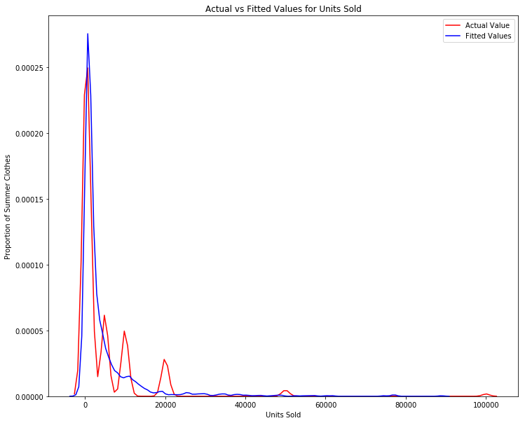

```python
width = 12
height = 10
plt.figure(figsize=(width, height))


ax1 = sns.distplot(dff['units_sold'], hist=False, color="r", label="Actual Value")
sns.distplot(yhat, hist=False, color="b", label="Fitted Values" , ax=ax1)


plt.title('Actual vs Fitted Values for Units Sold')
plt.xlabel('Units Sold')
plt.ylabel('Proportion of Summer Clothes')

plt.show()
```

**I: Polynomial Regression II**

```python
pr=PolynomialFeatures(degree=2)
Z_pr=pr.fit_transform(ZZ)
Input=[('scale',StandardScaler()), ('polynomial', PolynomialFeatures(include_bias=False)), ('model',LinearRegression())]
pipe=Pipeline(Input)
aa = df['units_sold']
```

```python
pipe.fit(ZZ,aa)
```

```
Pipeline(memory=None,
     steps=[('scale', StandardScaler(copy=True, with_mean=True, with_std=True)), ('polynomial', PolynomialFeatures(degree=2, include_bias=False, interaction_only=False)), ('model', LinearRegression(copy_X=True, fit_intercept=True, n_jobs=None,
         normalize=False))])
```

```python
ypipe=pipe.predict(ZZ)
```

```python
pipe.score(ZZ,aa)
```

```
0.8394708588418742
```

**Note: The Polynomial Regression actually fits this Regression better so I will stick with it**

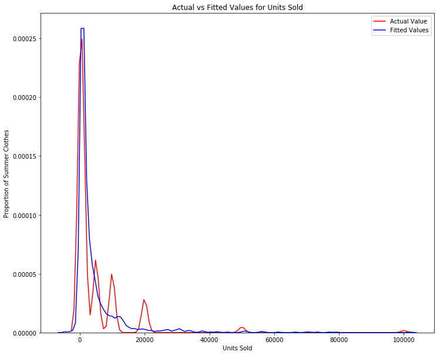

```python
width = 12
height = 10
plt.figure(figsize=(width, height))


ax1 = sns.distplot(dff['units_sold'], hist=False, color="r", label="Actual Value")
sns.distplot(ypipe, hist=False, color="b", label="Fitted Values" , ax=ax1)


plt.title('Actual vs Fitted Values for Units Sold')
plt.xlabel('Units Sold')
plt.ylabel('Proportion of Summer Clothes')

plt.show()
```

```python
b1 = ypipe[0]
b2 = ypipe[1]
b3 = ypipe[2]
b4 = ypipe[3]
b5 = ypipe[4]
b6 = ypipe[5]
```

```python
print('discount:',b1)
print('uses_ad_boosts:',b2)
print('rating_count:',b3)
print('merchant_rating_count:',b4)
print('product_variation_inventory:',b5)
print('has_urgency_banner:',b6)
```

```
discount: 1255.25
uses_ad_boosts: 26910.875
rating_count: -5.0
merchant_rating_count: 3408.4375
product_variation_inventory: 377.125
has_urgency_banner: 129.6875
```

# Step 3: Binning and Measuring Effect of Color of Clothes on Sales

**Why:** I am going to separate out clothes by color to determine whether there is a consumer preference for a certain color. Then I will run a simple regression to see if that color is significantly preferred in comparison to other colors.

**How:** I will do this by first going into SQL and slicing a dataset in order to get the 10 most common colors. Then I will use various binning techniques in Jupyter. I will also see what type of plots will be helpful in determining this.

# Associated SQL

**Understanding which colors were top 10 in sales:**

select TOP 10 product_color, count(product_color)product_color_count,sum(units_sold) color_units_sold, sum(price) color_price from summer-products group by product_color order by product_color_count desc

**Color Binning:**

Alter Table dbo.summer-products ADD ColorBin int GO

Update summer-products SET summer-products.ColorBin = case When product_color = 'black' then 1 When product_color = 'white' then 2 When product_color = 'yellow' then 3 When product_color = 'pink' then 4 When product_color = 'blue' then 5 When product_color = 'red' then 6 When product_color = 'green' then 7 When product_color = 'grey' then 8 When product_color = 'purple' then 9 When product_color = 'armygreen' then 10 else 11

End

**Understand which colors have highest average number of units sold:**

select ColorBin, sum(units_sold) color_units_sold, avg(units_sold) color_average_sold from summer-products Where ColorBin != 11 Group by ColorBin Order by color_average_sold desc

Note: We can see here that the top 5 in terms of average are purple, grey, black, white, and blue I'll make dummies of those 5 to see what their effects are on prices

**Creating Dummies of top average selling colors:**

Alter Table [dbo].[summer-products] ADD is_purple int ADD is_grey int ADD is_black int ADD is_white int ADD is_blue int

GO

Update [summer-products] SET [summer-products].[is_grey] = case When ColorBin = 8 then 1 else 0 END

Update [summer-products] SET [summer-products].[is_black] = case When ColorBin = 1 then 1 else 0 END

Update [summer-products] SET [summer-products].[is_white] = case When ColorBin = 2 then 1 else 0 END

Update [summer-products] SET [summer-products].[is_blue] = case When ColorBin = 5 then 1 else 0 END

Update [summer-products] SET [summer-products].[is_purple] = case When ColorBin = 9 then 1 else 0 END

select units_sold, (retail_price - price) discount, uses_ad_boosts, rating_count, merchant_rating_count, product_variation_inventory, has_urgency_banner, product_color, ColorBin, is_black, is_grey, is_purple, is_white, is_blue from summer-products

# Process

**A: Read in csv**

```python
cf = pd.read_csv('/Users/naasirhaleem/Desktop/Kaggle Projects/Wish/intermediate_csvs/Color/Color2.csv')
```

```python
cf = cf[cf['ColorBin'] != 11]
```

```python
cf.describe()
```

|  | units_sold | price | discount | uses_ad_boosts | rating_count | merchant_rating_count | rating | merchant_rating | rating_five_count | product_variation_inventory | shipping_option_price | countries_shipped_to | has_urgency_banner | ColorBin |
| --- | --- | --- | --- | --- | --- | --- | --- | --- | --- | --- | --- | --- | --- | --- |
| count | 1207.000000 | 1207.000000 | 1207.000000 | 1207.000000 | 1207.000000 | 1.207000e+03 | 1207.000000 | 1207.000000 | 1172.000000 | 1207.000000 | 1207.000000 | 1207.000000 | 368.0 | 1207.000000 |
| mean | 4130.657829 | 8.162974 | 14.933132 | 0.428335 | 867.460646 | 2.685009e+04 | 3.812461 | 4.026353 | 431.831058 | 33.154101 | 2.301574 | 40.741508 | 1.0 | 3.800331 |
| std | 8598.938507 | 3.624832 | 30.049323 | 0.495043 | 1963.340327 | 8.214522e+04 | 0.530819 | 0.206565 | 984.081239 | 21.341559 | 0.946420 | 20.233204 | 0.0 | 2.684777 |
| min | 1.000000 | 1.000000 | -3.000000 | 0.000000 | 0.000000 | 3.000000e+00 | 1.000000 | 2.333333 | 0.000000 | 1.000000 | 1.000000 | 6.000000 | 1.0 | 1.000000 |
| 25% | 100.000000 | 5.790000 | -1.000000 | 0.000000 | 22.500000 | 1.945500e+03 | 3.530000 | 3.914894 | 11.000000 | 6.000000 | 2.000000 | 32.000000 | 1.0 | 1.000000 |
| 50% | 1000.000000 | 8.000000 | 0.190000 | 0.000000 | 144.000000 | 8.166000e+03 | 3.830000 | 4.039495 | 78.000000 | 50.000000 | 2.000000 | 40.000000 | 1.0 | 3.000000 |
| 75% | 5000.000000 | 11.000000 | 17.000000 | 1.000000 | 856.000000 | 2.515750e+04 | 4.110000 | 4.156691 | 397.000000 | 50.000000 | 3.000000 | 43.000000 | 1.0 | 6.000000 |
| max | 100000.000000 | 26.000000 | 244.000000 | 1.000000 | 20744.000000 | 2.174765e+06 | 5.000000 | 4.577519 | 11548.000000 | 50.000000 | 7.000000 | 140.000000 | 1.0 | 10.000000 |

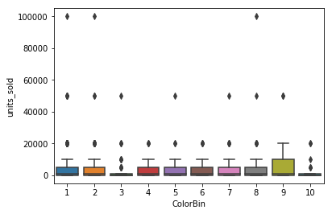

```python
sns.boxplot(x = "ColorBin", y = "units_sold", data = cf)
```

```python
pivot = cf.pivot_table(index = 'ColorBin', values = 'units_sold', aggfunc = 'sum')
```

```python
pivot
```

| ColorBin | units_sold |
| --- | --- |
| 1 | 1589313 |
| 2 | 1148227 |
| 3 | 222212 |
| 4 | 264500 |
| 5 | 326238 |
| 6 | 295300 |
| 7 | 291543 |
| 8 | 436190 |
| 9 | 338480 |
| 10 | 73701 |

**Note: Generally understand the breakup of the different colors. Now I want to see if there are significant differences.**

```python
cf1 = pd.read_csv('/Users/naasirhaleem/Desktop/Kaggle Projects/Wish/intermediate_csvs/Color/Color4.csv')
```

```python
cf1.head()
```

|  | units_sold | discount | uses_ad_boosts | rating_count | merchant_rating_count | product_variation_inventory | has_urgency_banner | product_color | ColorBin | is_black | is_grey | is_purple | is_white | is_blue |
| --- | --- | --- | --- | --- | --- | --- | --- | --- | --- | --- | --- | --- | --- | --- |
| 0 | 100 | -2.00 | 0 | 54 | 568 | 50 | 1.0 | white | 2 | 0 | 0 | 0 | 1 | 0 |
| 1 | 20000 | 14.00 | 1 | 6135 | 17752 | 50 | 1.0 | green | 7 | 0 | 0 | 0 | 0 | 0 |
| 2 | 100 | 35.00 | 0 | 14 | 295 | 1 | 1.0 | leopardprint | 11 | 0 | 0 | 0 | 0 | 0 |
| 3 | 5000 | 0.00 | 1 | 579 | 23832 | 50 | NaN | black | 1 | 1 | 0 | 0 | 0 | 0 |
| 4 | 100 | 0.28 | 1 | 20 | 14482 | 1 | 1.0 | yellow | 3 | 0 | 0 | 0 | 0 | 0 |

```python
cf1.corr()
```

|  | units_sold | discount | uses_ad_boosts | rating_count | merchant_rating_count | product_variation_inventory | has_urgency_banner | ColorBin | is_black | is_grey | is_purple | is_white | is_blue |
| --- | --- | --- | --- | --- | --- | --- | --- | --- | --- | --- | --- | --- | --- |
| units_sold | 1.000000 | 0.016369 | -0.016055 | 0.899464 | 0.272897 | 0.133846 | NaN | 0.021042 | 0.045715 | 0.041945 | 0.040874 | 0.006085 | -0.029991 |
| discount | 0.016369 | 1.000000 | -0.026678 | 0.055884 | 0.033292 | 0.085961 | NaN | -0.019120 | 0.044092 | -0.038595 | -0.006365 | 0.029113 | 0.011173 |
| uses_ad_boosts | -0.016055 | -0.026678 | 1.000000 | -0.043936 | 0.029735 | -0.135384 | NaN | 0.010068 | 0.012839 | 0.020160 | -0.028054 | -0.025206 | -0.027834 |
| rating_count | 0.899464 | 0.055884 | -0.043936 | 1.000000 | 0.258168 | 0.134246 | NaN | -0.010724 | 0.083835 | 0.041945 | 0.019182 | -0.003186 | -0.026260 |
| merchant_rating_count | 0.272897 | 0.033292 | 0.029735 | 0.258168 | 1.000000 | 0.083577 | NaN | -0.017620 | 0.041428 | 0.075615 | -0.002353 | 0.013923 | -0.019704 |
| product_variation_inventory | 0.133846 | 0.085961 | -0.135384 | 0.134246 | 0.083577 | 1.000000 | NaN | -0.075007 | 0.135080 | -0.031098 | -0.012761 | 0.015232 | 0.027203 |
| has_urgency_banner | NaN | NaN | NaN | NaN | NaN | NaN | NaN | NaN | NaN | NaN | NaN | NaN | NaN |
| ColorBin | 0.021042 | -0.019120 | 0.010068 | -0.010724 | -0.017620 | -0.075007 | NaN | 1.000000 | -0.570932 | 0.142763 | 0.171183 | -0.399493 | -0.032227 |
| is_black | 0.045715 | 0.044092 | 0.012839 | 0.083835 | 0.041428 | 0.135080 | NaN | -0.570932 | 1.000000 | -0.106631 | -0.091581 | -0.216735 | -0.127788 |
| is_grey | 0.041945 | -0.038595 | 0.020160 | 0.041945 | 0.075615 | -0.031098 | NaN | 0.142763 | -0.106631 | 1.000000 | -0.040599 | -0.096080 | -0.056649 |
| is_purple | 0.040874 | -0.006365 | -0.028054 | 0.019182 | -0.002353 | -0.012761 | NaN | 0.171183 | -0.091581 | -0.040599 | 1.000000 | -0.082519 | -0.048654 |
| is_white | 0.006085 | 0.029113 | -0.025206 | -0.003186 | 0.013923 | 0.015232 | NaN | -0.399493 | -0.216735 | -0.096080 | -0.082519 | 1.000000 | -0.115143 |
| is_blue | -0.029991 | 0.011173 | -0.027834 | -0.026260 | -0.019704 | 0.027203 | NaN | -0.032227 | -0.127788 | -0.056649 | -0.048654 | -0.115143 | 1.000000 |

**B: Run OLS to determine if there is true preference that leads to unit sales**

```python
Z = cf1[['is_black','is_blue','is_white','is_grey','is_purple']]
a = cf1['units_sold']
```

```python
X = Z
y = a
X2 = sm.add_constant(X)
est = sm.OLS(y, X2)
est2 = est.fit()
print(est2.summary())
```

```
                            OLS Regression Results
==============================================================================
Dep. Variable:             units_sold   R-squared:                       0.008
Model:                            OLS   Adj. R-squared:                  0.004
Method:                 Least Squares   F-statistic:                     2.382
Date:                Thu, 01 Oct 2020   Prob (F-statistic):             0.0365
Time:                        16:59:00   Log-Likelihood:                -16609.
No. Observations:                1573   AIC:                         3.323e+04
Df Residuals:                    1567   BIC:                         3.326e+04
Df Model:                           5
Covariance Type:            nonrobust
==============================================================================
                 coef    std err          t      P>|t|      [0.025      0.975]
------------------------------------------------------------------------------
const       3795.1804    332.794     11.404      0.000    3142.412    4447.949
is_black    1415.6819    629.705      2.248      0.025     180.530    2650.834
is_blue     -532.8004    991.145     -0.538      0.591   -2476.911    1411.310
is_white     672.6289    670.748      1.003      0.316    -643.028    1988.286
is_grey     2348.3407   1156.884      2.030      0.043      79.137    4617.545
is_purple   2591.2347   1324.882      1.956      0.051      -7.493    5189.962
==============================================================================
Omnibus:                     1759.959   Durbin-Watson:                   1.872
Prob(Omnibus):                  0.000   Jarque-Bera (JB):           144843.823
Skew:                           5.620   Prob(JB):                         0.00
Kurtosis:                      48.647   Cond. No.                         6.02
==============================================================================

Warnings:
[1] Standard Errors assume that the covariance matrix of the errors is correctly specified.
```

**Black**

**Grey**

**Purple**

This would lead me to predict that these would likely be the top performing colors in the next year of Summer Sales.

# Conclusions

1: Correlation Table

```
a. From the correlation table with the following list of factors: price, discount, uses ad boosts, rating, and merchant rating, I can see that none of these factors had a particularly strong correlation with units sold.
```

2: Multilinear and Polynomial Regressions

[output not shown]

3: Generally Predicting Unit Sales of Summer Clothes in 2021

[output not shown]